# Week 1: The Digital Population

Lecture

Mohammed Ali Sharafuddin

## Week 1 Lecture: The Digital Population

Discussion

**1 Introduction**

⏱ 10 min

Welcome, module aims, recall quiz on digital participation

Content

**2 Web 4.0 and Participation**

⏱ 30 min

Signals, footprints, ethics, persona, U&G, social contagion, worked case

Practice

**3 Guided Discussion**

⏱ 15 min

“What can we safely infer from public signals?”

Assessment

**4 Attendance and Exit Check**

⏱ 5 min

Attendance, Moodle concept check

## Module Arc

**Weeks 1–2**

Foundations and Planning

→

**Weeks 3–5**

Content and Media

→

**Weeks 6–8**

Acquisition Channels

→

**Weeks 9–12**

Relationships and Measurement

→

**Weeks 13–15**

Governance and AI

> **We are here, in Weeks 1 and 2: Foundations and Planning.** The persona you build today is the audience input for every week that follows.

## What We Cover Today (1 of 2)

Concepts and theory:

1. **The digital population**: the measurable environment of users, devices, platforms, and traces
2. **Web evolution**: five stages from broadcast to AI-mediated discovery, and the marketing implication of each
3. **Digital footprints and audience signals**: reading public traces carefully and classifying their limits
4. **The evidence framework**: separating evidence, inference, assumption, and recommendation
5. **Uses and gratifications theory**: why people choose particular channels for particular purposes

## What We Cover Today (2 of 2)

Application and production:

6. **Social contagion**: why some messages travel through networks and others stop at the first receiver
7. **Building the persona**: constructing a compact, evidence-grounded argument about the audience
8. **Ethical interpretation**: why careful wording is also stronger strategy
9. **Channel fit and the media plan**: connecting the persona to a structured week of activity
10. **AI protocol**: the no-evidence, no-claim rule and the prompt log requirement

> The tutorial produces two artefacts: a one-paragraph persona and a five-day media plan. Everything in this lecture prepares you for that task.

## Learning Objectives (1 of 2)

After studying this chapter, you should be able to:

1. Explain the meaning of **digital population**, **Web 2.0 participation**, **digital footprint**, **audience signal**, **persona**, and **channel fit**.
2. Separate **evidence**, **inference**, **assumption**, and **recommendation** in early campaign planning.
3. Use **uses and gratifications theory** to explain why people choose particular digital media.
4. Explain how **social contagion** shapes the spread of digital messages.
5. Interpret public digital signals **cautiously**.

## Learning Objectives (2 of 2)

After studying this chapter, you should be able to:

6. Draft an **evidence-informed persona**.
7. Build a **one-week media plan** that connects objective, channel, message, format, resource constraint, and metric.
8. Recognise **ethical limits** when using public online behaviour for marketing decisions.
9. Use public tools such as **Google Trends** and **Market Finder**, or equivalent market insight tools, to document search interest, regional signals, related queries, and priority market cues.

> **Every one of these nine objectives will be assessed in your Week 1 submission.** Identify the two you feel least confident about and focus your six self-directed hours there.

## The Digital Population

> The people, devices, platforms, communities, habits, data traces, and social contexts that form the environment in which digital marketing works.

**Knowing your audience is the analytical foundation of every effective campaign.**

## What is the Digital Population?

> A **digital population** is the collection of users, devices, platforms, and data interactions that form a measurable audience environment for campaign planning. It is **active**: people search, compare, review, share, ignore, and challenge.

**Digital marketing is therefore a form of disciplined listening as much as a form of promotion.**

A campaign team can choose a channel, write a caption, or set a budget only after it has a working account of how people search, learn, compare, trust, and decide in digital environments.

## The Extended Marketing Environment

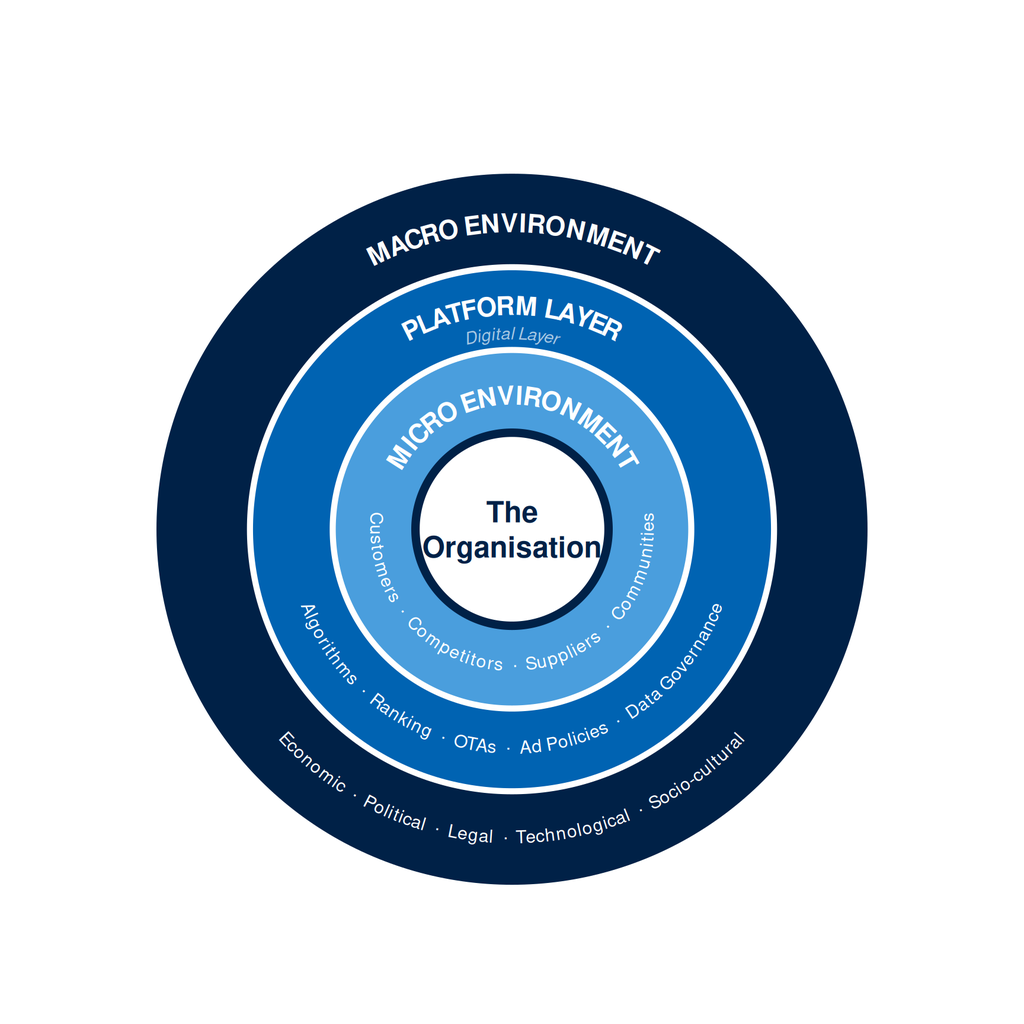

## The Same Four Forces: Audience View

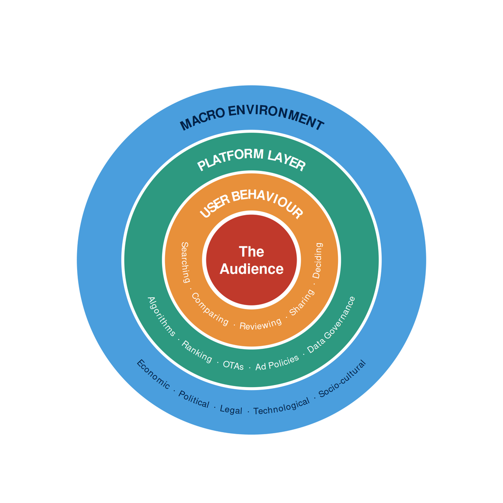

> A campaign’s job is to find where a well-placed message fits into what the audience is **already doing**.

## Web Evolution: The Audience Role at Each Stage

> The web has moved through several overlapping stages. These stages **coexist today**. Every campaign operates across all five simultaneously.

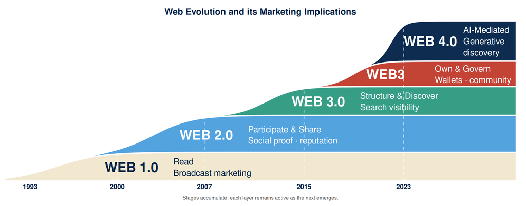

## Web 1.0 and Web 2.0

| Stage | Typical pattern | Marketing implication |
| --- | --- | --- |
| **Web 1.0** *(mid-to-late 1990s)* | Organisations publish; users read | Information architecture and credibility matter |
| **Web 2.0** *(2004 to present)* | Users create, share, review, and interact | Participation, social proof, and community matter |

**Web 2.0 is the most important shift for your campaign work right now.**

A hotel description is read alongside guest reviews. A university advertisement is interpreted alongside student comments. A product claim is compared with unboxing videos, forum discussions, and peer recommendations.

## Web 3.0 and Web3

| Stage | Typical pattern | Marketing implication |
| --- | --- | --- |
| **Web 3.0 / Semantic Web** | Data becomes machine-readable and connectable | Search visibility, structured content, and AI discovery matter |
| **Web3 / Decentralised** | Users hold tokens, wallets, and community governance rights | Trust, ownership, and community design matter |

> All five stages **coexist right now**. A static hotel website (Web 1.0) sits alongside TripAdvisor reviews (Web 2.0), structured schema markup (Web 3.0), a wallet-based loyalty programme (Web3), and AI-generated search summaries (Web 4.0).

## Web 4.0: AI-Mediated Discovery

| Stage | Typical pattern | Marketing implication |
| --- | --- | --- |
| **Web 4.0 / AI-Mediated** | AI assistants, recommendation engines, and generative search summarise and filter content before a human reads it | Campaign content must be clear, specific, and structured enough for AI to represent accurately |

> A traveller searching for a guesthouse may receive an AI-generated summary. A student researching a career path may read a synthesised answer from dozens of sources. **A campaign that survives AI paraphrasing has proven its clarity.**

> All five stages coexist. A static page (Web 1.0) sits alongside reviews (Web 2.0), schema markup (Web 3.0), a wallet-based loyalty scheme (Web3), and AI-generated discovery summaries (Web 4.0).

## Footprints, Signals, and Evidence

> A **digital footprint** is a trace created by online activity.

> An **audience signal** is an interpreted clue about audience interest, need, language, behaviour, or context.

**Signals begin inquiry. Fuller evidence completes it.**

## What is a Digital Footprint?

A **digital footprint** is the full collection of traces an individual creates through online activity. Three types:

| Type | How it arises | Access for marketers |
| --- | --- | --- |
| **Deliberate** | Reviews, comments, posts, ratings, shared videos, public questions: actively chosen to create | Observable without entering a private system |
| **Behavioural** | Page views, search queries, clicks, scrolls, form starts, email opens: recorded automatically as you navigate | Require lawful basis and proper governance |
| **Mandatory** | Identity, payment details, and travel dates collected to satisfy financial and consumer-protection regulations | Held by platforms or regulators; not directly accessible |

**In Week 1, we focus on deliberate, public traces only.**

Trend data, search suggestions, public questions, public reviews, and credible reports are enough to begin meaningful campaign thinking.

## What is an Audience Signal?

> An **audience signal** is an interpreted clue about audience interest, need, language, behaviour, or context. The same footprint can support more than one reading.

The value of a signal comes from **disciplined interpretation**, not quick certainty.

| Footprint observed | Audience signal | Caution |
| --- | --- | --- |
| Rising searches for “analytics alternative” | Increasing interest in switching tools | May reflect news, not actual demand |
| Related searches mentioning cost | Price is part of the evaluation | Does not prove unaffordability |
| Reviews praising convenience | Ease of use matters | Convenience means different things |
| Repeated public questions about logistics | Missing information or low confidence | Questions from one segment only |
| Widely shared short video | That format travels well in this network | Sharing motive may differ from topic |

## From Trace to Recommendation: The Signal Chain

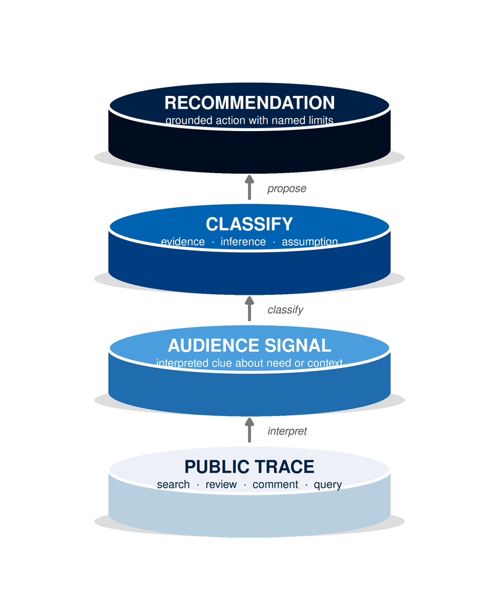

> Every planning statement must be classifiable as one of the four categories. Mix them up and the campaign is built on an unstated assumption.

## The Discipline of Interpretation

Three things to remember when reading any footprint:

1. **Describe before you interpret.** Record what you observe (the footprint) before you state what it may mean (the signal). These are different claims with different levels of certainty.
2. **State the limit.** Every trace has something it cannot prove. A rising trend line does not prove demand. A review pattern does not represent the silent majority. Say this explicitly in your submission.
3. **Signal opens inquiry; evidence completes it.** A signal is the starting point for a research question, not the answer to it. Use signals to decide what to investigate next, not to finalise the campaign.

> **Caution label for every signal:** “This may indicate [X]. It does not prove [Y]. To confirm, I would need [Z].”

## The Evidence Framework

> Early campaign work often fails when observations, interpretations, guesses, and proposed actions are mixed together without acknowledgement.

> **Four categories keep the thinking clear.**

## Evidence, Inference, Assumption, Recommendation

| Category | Definition | Language to use |
| --- | --- | --- |
| **Evidence** | Material you can show: a trend chart, screenshot, public question, report, or source quotation | “The data shows…”, “The review states…”, “According to…” |
| **Inference** | A reasonable interpretation of documented evidence | “This may indicate…”, “This appears to suggest…”, “One reading is…” |
| **Assumption** | A belief that still needs testing and could be wrong | “We are assuming…”, “This has not yet been confirmed…”, “To verify this, we would need…” |
| **Recommendation** | The action you propose, grounded in evidence and limited by named assumptions | “We recommend testing…”, “On the basis of the above evidence, we propose…” |

> Experienced clients, markers, and campaign teams notice when these four are mixed without labelling. Keeping them separate is the first step to analytical credibility.

## EIAR in Practice: Two Scenarios

| Scenario | Statement | Category |
| --- | --- | --- |
| Short course in marketing analytics | Related searches include "free analytics tools" and "Google Analytics alternative". | Evidence |
|  | Some users appear interested in low-cost or accessible analytics options. | Inference |
|  | These users will prefer a course that teaches open-source tools. | Assumption |
|  | Test a message that highlights practical analytics skills using accessible tools. | Recommendation |
| B2B supplier of open-source analytics support | Public tender notices mention "self-hosted analytics" and "data residency". | Evidence |
|  | Some organisations may be looking for analytics options that keep data under local control. | Inference |
|  | Procurement teams will prioritise open-source analytics support over commercial analytics suites. | Assumption |
|  | Test a landing page section that explains self-hosting, data control, support response time, and implementation cost. | Recommendation |

## All Four: Maldivian Guesthouse Scenario

[output not shown]

## The EIAR Framework: Four Levels of Epistemic Distance

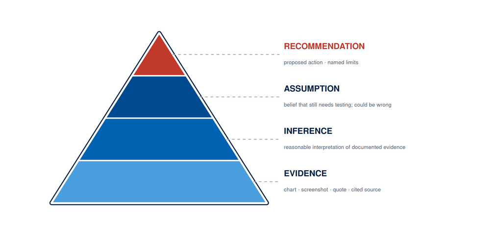

## Uses and Gratifications Theory *(Katz et al., 1973)*

> People **actively choose** media to satisfy specific needs. The right campaign question: what is the audience trying to accomplish here, and which channel serves that purpose?

[interactive chart not shown]

## Why People Choose Media

Uses and gratifications theory (1973) challenged the passive-audience model.

> People **actively select** media to satisfy specific needs. A platform is a **situation** people enter with particular expectations, and campaign messages succeed or fail on whether they fit those expectations.

| Old question | New question |
| --- | --- |
| “Which platform has the most users?” | “What is the audience trying to accomplish in this channel?” |
| “Where is our budget most efficient?” | “What need does our message serve, and where is that need active?” |
| “What content performs best?” | “What purpose does this content serve for the person receiving it?” |

## Six Audience Needs and Channel Fit

| Audience need | Channel fits | Metric |
| --- | --- | --- |
| **Information** | Search pages, FAQs, explainers, comparison pages | Page views, scroll depth, time on page |
| **Entertainment** | Short-video platforms, YouTube Shorts, Reels | Video completion rate, saves |
| **Social connection** | Communities, forums, social posts, messaging groups | Shares, saves, comments, replies |
| **Identity** | LinkedIn, brand communities, creator ecosystems | Profile follows, engagement, community joins |
| **Convenience** | Mobile landing pages, WhatsApp, streamlined forms | Form starts, click-to-call, save rate |
| **Reassurance** | OTA listings, review platforms, case-study pages | Time on page, testimonial clicks, return visits |

> **Modern algorithms also mediate gratification.** Someone opens an app for entertainment but the algorithm identifies them as a likely buyer and serves a product tutorial. Campaign planners must consider both the audience’s stated purpose and the platform’s likely distribution logic.

## Social Contagion *(Berger, 2013)*

> U&G explains why people **choose** channels. Social contagion explains why some messages **travel** while others stop at the first receiver.

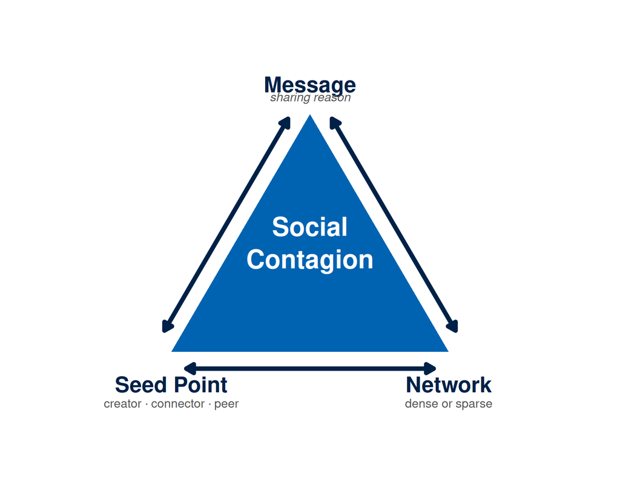

## Five Reasons People Share

1. **Practical value**: a checklist, guide, calculator, or template saves effort for someone else. It travels because sharing it makes the sender look helpful.
2. **Identity**: sharing the content helps a person express belonging or aspiration. It travels through networks of people who share that identity.
3. **Emotion**: the message creates a genuine feeling: pride, humour, concern, or hope. **Use responsibly.** Manufactured outrage or false urgency can generate short-term sharing while damaging long-term trust.
4. **Social proof**: visible participation by credible others lowers uncertainty. Reviews, endorsements, tagged photos, and community recommendations all carry social proof.
5. **Conversation**: the topic is clear, relevant, and easy to summarise in one sentence. If someone cannot explain your campaign to a friend in thirty seconds, it lacks conversational currency.

## Building the Persona

> A **persona** is what you use to bring your audience into focus. It lets you gather your evidence, your theory, and your named assumptions into one working description, specific enough to test every channel, format, and message against a single question: does this serve the person I described?

**A persona is a compact argument, not a fictional demographic sketch.**

## Seven Elements of a Strong Persona

| Element | What it captures |
| --- | --- |
| **Audience segment** | Who they are: role, context, and situation |
| **Situation or problem** | What they are dealing with right now |
| **Motivation** | Why they are looking for a solution |
| **Barrier or doubt** | What is stopping them from acting: the most strategically important element |
| **Media-use habits** | Where and how they consume information or make decisions |
| **Evidence** | The documented traces that support each claim |
| **Assumptions** | What the evidence does not prove, and what needs further testing |

## Example Persona: Maldivian Guesthouse

**Evidence base:** Rising Trends interest in “local island Maldives” and “budget Maldives guesthouse”; 12 of 20 OTA reviews mention logistics, airport transfers, or equipment; tourism ministry report: guesthouse stays up 34%, 78% of bookings via OTA.

> An international traveller aged 25 to 40 who has researched Maldives holidays and found resort prices prohibitive. They are seriously considering a local island stay but are uncertain about logistics, connectivity, and whether the experience will match their expectations. They actively read guest reviews and comparison posts before booking. Their main barrier is a lack of clear, detailed information about arrival, facilities, and daily logistics.

> **Discussion:** which element of this persona is an assumption that would need primary research to confirm?

## Ethical Interpretation

> Every public trace you collect describes real people’s behaviour. Handling it with care is both the ethical requirement and the analytical discipline that keeps your persona credible.

> Careful interpretation is not just more ethical: it is also more strategically useful.

## Ethics and Strategy Are the Same Discipline

| Ethical constraint | Strategic constraint | Both resolved by |
| --- | --- | --- |
| Do not stereotype a group | Stereotypes produce poorly targeted campaigns | Use specific evidence, not demographic assumptions |
| Do not overstate certainty | Overconfident claims cannot be defended to clients | Use cautious language and label assumptions |
| Do not use data carelessly | Careless data use signals analytical weakness | Document sources, dates, and collection methods |
| Respect the limits of public data | Exceeding those limits produces wrong strategies | State what the evidence cannot prove |

| Careless wording | Careful wording |
| --- | --- |
| “People searching this are desperate” | “Rising search interest may indicate active problem-solving behaviour” |
| “Price questions mean they cannot afford it” | “Price questions indicate that cost is part of the evaluation, not that the offer is unaffordable” |
| “Everyone in this community thinks X” | “A sample of public comments suggests X; the silent majority’s view remains unknown” |

## Channel Fit and the Media Plan

> **Channel fit** is the match between the audience’s purpose, the campaign goal, the message format, available resources, and the behaviour that will be measured.

A channel has **strong fit** when people already use it for the kind of task the campaign supports.

## Goals, Channels, and Metrics

| Campaign goal | Channel fits | Possible metrics |
| --- | --- | --- |
| **Awareness** | Short video, display, social content, creator mentions | Reach, video completion rate, profile visits |
| **Question-answering** | Search pages, FAQs, explainers, webinars | Page views, scroll depth, time on page |
| **Enquiry generation** | Landing pages, email, search ads, lead forms | Form starts, enquiry clicks, submissions |
| **Sharing** | Useful guides, checklists, event posts, referral messages | Shares, saves, forwarded emails |
| **Decision support** | Comparison pages, testimonials, case studies | Clicks to apply, downloads, return visits |

## Sequential Campaign Logic

A five-day plan is a **five-day argument** that builds from attention to action, with each day preparing the audience for the next.

| Stage | Day | Audience intent | Campaign role |
| --- | --- | --- | --- |
| **Attention** | Mon | Searching for an answer | Be the clear, findable answer |
| **Relevance** | Tue | Scrolling, comparing | Interrupt with a relevant problem statement |
| **Resource** | Wed | Ready to learn | Offer something useful they can keep and share |
| **Proof** | Thu | Evaluating options | Show, do not tell: demonstrate the skill or outcome |
| **Action** | Fri | Considering a decision | Make the next step obvious and low-effort |

> If Tuesday’s click-through rate is very low, Friday’s retargeting audience will be thin. Read each metric before committing to the next day’s activity.

## Example One-Week Media Plan

| Day | Channel | Message | Format | Metric |
| --- | --- | --- | --- | --- |
| Monday | Search-friendly landing page | Learn which marketing numbers actually matter | FAQ and course overview | Page views and scroll depth |
| Tuesday | Social post | Stop guessing whether your posts work | Short carousel | Click-through rate |
| Wednesday | Email | Free checklist: campaign metrics for small businesses | Email with checklist link | Checklist clicks |
| Thursday | Short video | Three analytics mistakes small businesses make | Captioned 45-second video | 50% video completion |
| Friday | Reminder post | Join the practical analytics workshop | Graphic with clear call to action | Registration-start clicks |

> Every row needs a reason and every reason needs a measurable signal. A campaign becomes clearer when goal, channel, message, format, and metric all align.

## The AI Protocol

> **No evidence, no claim.**

> AI output is a working note. Connect every claim to a documented public trace before using it. If AI suggests the audience is “price-sensitive,” “anxious,” “ready to buy,” or “tech-savvy,” verify that claim against an evidence source or remove it.

## What Good AI Use Looks Like in Week 1

| Permitted and useful | Not permitted |
| --- | --- |
| Ask AI to suggest search terms for Trends | Ask AI to describe your audience without any evidence |
| Show AI your screenshot; ask for possible inferences | Accept AI audience descriptions without verifying against a public trace |
| Ask AI to identify missing elements in your media plan | Submit AI-generated citations or market facts without a source |
| Ask AI to check whether a persona claim is supported | Submit AI-generated persona wording without a prompt log |
| Ask AI to suggest alternative interpretations of a trace | Use AI to fill in the evidence worksheet without actual evidence |

> **Every AI-assisted claim in your submission must link to a documented evidence item in your prompt log.** AI output without an evidence link must be removed or rewritten as a labelled assumption.

> A submission without a prompt log will be returned for resubmission regardless of content quality.

## Key Takeaways (1 of 2)

- **Digital marketing starts with digital life**: the routines, questions, comparisons, and traces that shape how people decide
- **Public traces are useful only when interpreted carefully**: classify every claim as evidence, inference, assumption, or recommendation
- **Uses and gratifications** explains why people choose channels; **social contagion** explains why messages travel through networks
- **A persona is a compact argument** built from evidence, not a fictional demographic sketch with a stock photo

## Key Takeaways (2 of 2)

- **AI supports** evidence interpretation; evidence collection and independent judgement remain yours
- **Channel fit** connects the persona to the media plan; goal, channel, message, format, and metric must all align
- **No evidence, no claim**: every statement about the audience must trace to a documented source or be labelled explicitly as an assumption

## Next Steps

**Before you move into the tutorial, answer these three questions:**

1. **What decision does your evidence support?** *(Name one specific claim the evidence justifies.)*
2. **What remains uncertain?** *(Name one assumption that would need primary research to confirm.)*
3. **What ethical risk did you identify?** *(Name one limit of using public traces in this campaign.)*

> Write these down now. They are the first three sentences of your 300-word reflection. Written immediately, they will be sharper and more specific than anything reconstructed the night before the deadline.